# Optimizing Insurance Complaint Classification Exploratory Data Analysis

2024-04-06

# Predicting Complaint Types in Insurance Companies

Predicting complaint types in insurance companies can provide several benefits and avenues for increasing productivity and efficiency:

1. **Improved Customer Service**:
   - By accurately predicting complaint types, insurance companies can proactively address customer issues and concerns.
   - This can lead to higher customer satisfaction, improved retention rates, and positive word-of-mouth referrals.
2. **Resource Allocation**:
   - Understanding the types and frequency of complaints allows companies to allocate resources more effectively.
   - They can prioritize areas that receive the most complaints, ensuring that resources are allocated where they are most needed.
3. **Risk Management**:
   - Analyzing complaint types can help identify potential risks and areas of vulnerability within the company’s operations.
   - By addressing these issues proactively, companies can mitigate risks and avoid costly legal disputes or regulatory penalties.
4. **Product Development**:
   - Insights from complaint data can inform product development and innovation.
   - By understanding customer pain points and preferences, companies can develop new products or improve existing ones to better meet customer needs.
5. **Process Optimization**:
   - Analyzing complaint data can highlight inefficiencies or bottlenecks in internal processes.
   - Companies can use this information to streamline workflows, automate repetitive tasks, and improve overall operational efficiency.
6. **Training and Education**:
   - Identifying common complaint types can guide training programs for employees.
   - Companies can provide targeted training to address specific areas of concern, improving employee competency and performance.
7. **Regulatory Compliance**:
   - Compliance with regulatory requirements is essential in the insurance industry.
   - Analyzing complaint data can help ensure that companies are meeting regulatory standards and requirements, reducing the risk of non-compliance and associated penalties.
8. **Competitive Advantage**:
   - Companies that effectively analyze and respond to complaint data can gain a competitive advantage in the market.
   - By providing superior customer service and addressing customer concerns promptly, companies can differentiate themselves from competitors and attract more customers.

```r
library(dplyr)
```

```r
library(ggplot2)
library(janitor)
library(parsnip)
library(tidyverse)
library(tidymodels)
library(ranger)
library(tidyverse)
library(tidymodels)
library(ranger)
library(caret)
library(randomForest)
library(MASS)
library(purrr)
library(arulesViz)
library(arules)
library(ggwordcloud)
```

```r
insurance <- read.csv("Insurance_complaints__All_data.csv")
dim(insurance)
```

```
## [1] 50238    16
```

```r
insurance <- insurance |> dplyr::select(-X)
```

```r
column_counts_df <- data.frame(Column_Name = character(), Unique_Count = numeric(), stringsAsFactors = FALSE)

# Iterate over columns of the original data frame
for (col in names(insurance)) {
  # Calculate unique count of values in each column
  unique_count <- length(unique(insurance[[col]]))
  # Append column name and unique count to the new data frame
  column_counts_df <- rbind(column_counts_df, data.frame(Column_Name = col, Unique_Count = unique_count))
}

# Display the new data frame
print(column_counts_df)
```

```
##                Column_Name Unique_Count
## 1  complaint_filed_against          552
## 2       complaint_filed_by           21
## 3   reason_complaint_filed          103
## 4      confirmed_complaint            2
## 5             how_resolved           38
## 6           complaint_type            4
## 7            coverage_type            7
## 8           coverage_level           22
## 9          others_involved           55
## 10           respondent_id          447
## 11         respondent_role           27
## 12         respondent_type            2
## 13        complainant_type            2
## 14                keywords           64
## 15         date_difference          406
```

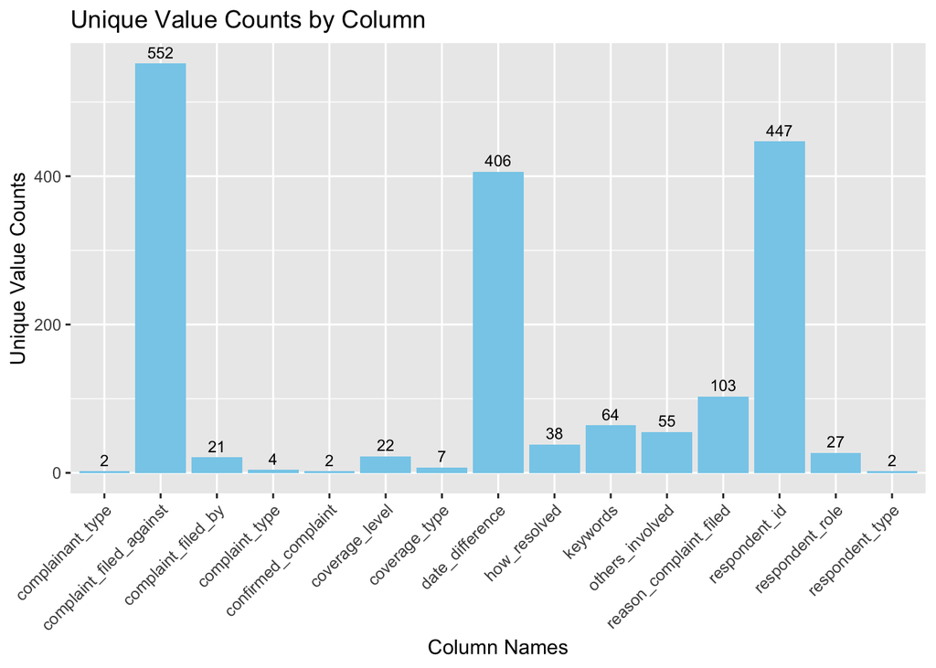

```r
# Create a vertical bar plot with counts on top
plot <- ggplot(column_counts_df, aes(x = Column_Name, y = Unique_Count)) +
  geom_bar(stat = "identity", fill = "skyblue") +
  geom_text(aes(label = Unique_Count), vjust = -0.5, color = "black", size = 3) +  # Add counts on top of bars
  labs(title = "Unique Value Counts by Column",
       x = "Column Names",
       y = "Unique Value Counts") +
  theme(axis.text.x = element_text(angle = 45, hjust = 1))  # Rotate x-axis labels for better readability

# Print the plot
print(plot)
```

```r
insurance_df <- insurance

# Frequency table for 'Complaint_Type'
complaint_type_freq <- table(insurance_df$complaint_type)
print(complaint_type_freq)
```

```
##
##       Independent Review Org                       Portal
##                         8537                         7181
##    Teacher Retirement System Workers Compensation Network
##                        21485                        13035
```

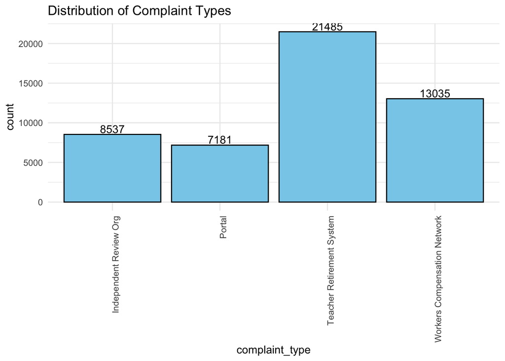

```r
theme_set(theme_bw())

# Bar plot for 'Complaint_Type' with counts displayed on top of each bar
ggplot(data = insurance_df, aes(x = complaint_type)) +
  geom_bar(fill = "skyblue", color = "black") +
  geom_text(stat = 'count', aes(label = ..count..), vjust = -0.2) +  # Add counts on top of each bar
  labs(title = "Distribution of Complaint Types") +
  theme_minimal() +
  theme(axis.text.x = element_text(angle = 90, hjust = 1))
```

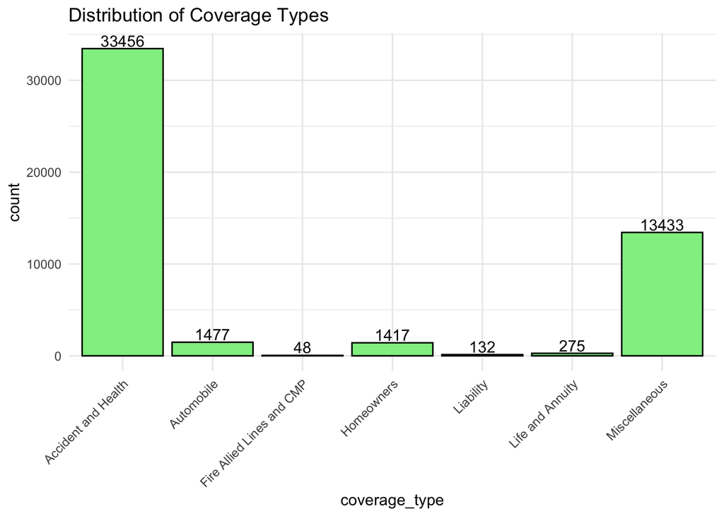

```r
# Bar plot for 'Coverage_Type'
ggplot(data = insurance_df, aes(x = coverage_type)) +
  geom_bar(fill = "lightgreen", color = "black") +
  geom_text(stat = 'count', aes(label = ..count..), vjust = -0.2) +
  labs(title = "Distribution of Coverage Types") +
  theme_minimal() +
  theme(axis.text.x = element_text(angle = 45, hjust = 1))
```

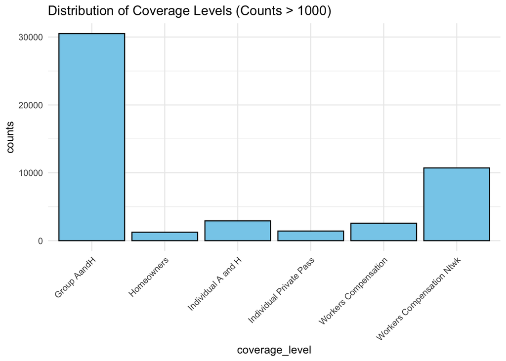

```r
insurance_df |>
  group_by(coverage_level)|>
  summarise(counts = n())|>
  filter(counts > 1000)|>
  ggplot(aes(x = coverage_level, y = counts)) +
  geom_bar(stat = "identity", fill = "skyblue", color = "black") +
  labs(title = "Distribution of Coverage Levels (Counts > 1000)") +
  theme_minimal() +
  theme(axis.text.x = element_text(angle = 45, hjust = 1))
```

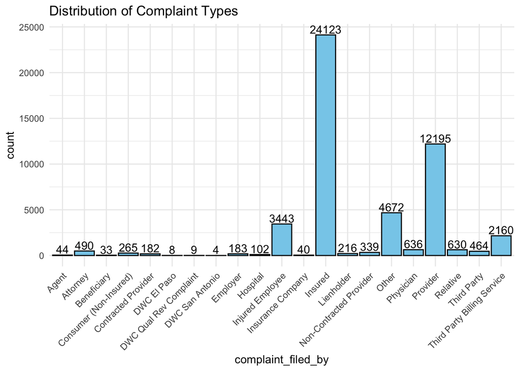

```r
ggplot(data = insurance, aes(x = complaint_filed_by)) +
  geom_bar(fill = "skyblue", color = "black") +
  geom_text(stat = 'count', aes(label = ..count..), vjust = -0.2) +  # Add counts on top of each bar
  labs(title = "Distribution of Complaint Types") +
  theme_minimal() +
  theme(axis.text.x = element_text(angle = 45, hjust = 1))
```

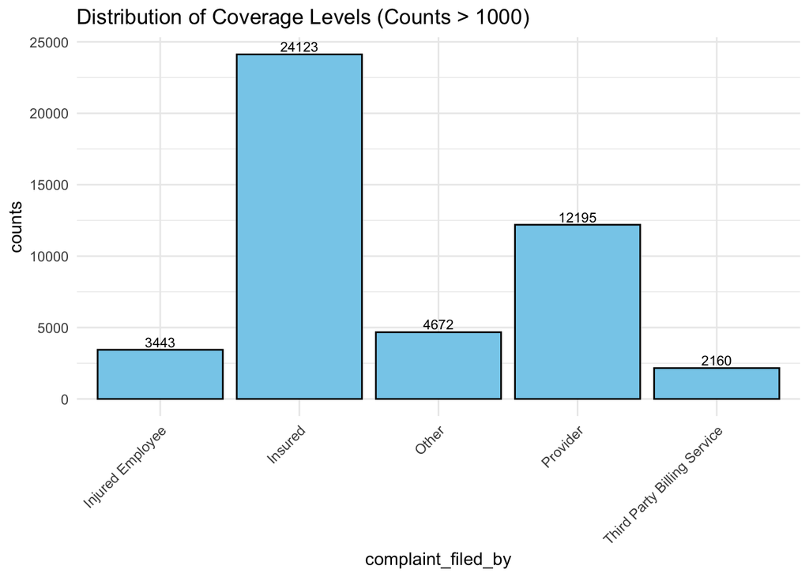

```r
insurance |>
  group_by(complaint_filed_by)|>
  summarise(counts = n())|>
  filter(counts > 1000)|>
  ggplot(aes(x = complaint_filed_by, y = counts)) +
  geom_bar(stat = "identity", fill = "skyblue", color = "black") +
  labs(title = "Distribution of Coverage Levels (Counts > 1000)") +
  geom_text(aes(label = counts), vjust = -0.3, color = "black", size = 3) +
  theme_minimal() +
  theme(axis.text.x = element_text(angle = 45, hjust = 1))
```

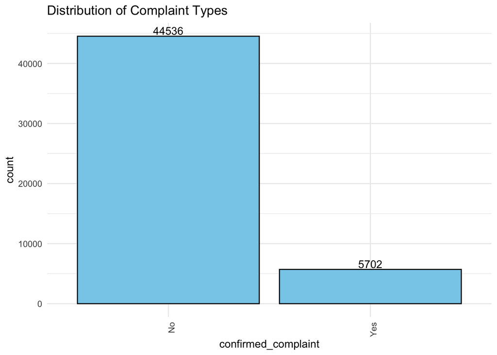

```r
insurance_df <- insurance

ggplot(data = insurance_df, aes(x = confirmed_complaint)) +
  geom_bar(fill = "skyblue", color = "black") +
  geom_text(stat = 'count', aes(label = ..count..), vjust = -0.2) +  # Add counts on top of each bar
  labs(title = "Distribution of Complaint Types") +
  theme_minimal() +
  theme(axis.text.x = element_text(angle = 90, hjust = 1))
```

```r
# Convert dataframe to transactions
transactions <- as(insurance_df, "transactions")
# Perform association rule mining
rules <- apriori(transactions)
```

```
## Apriori
##
## Parameter specification:
##  confidence minval smax arem  aval originalSupport maxtime support minlen
##         0.8    0.1    1 none FALSE            TRUE       5     0.1      1
##  maxlen target  ext
##      10  rules TRUE
##
## Algorithmic control:
##  filter tree heap memopt load sort verbose
##     0.1 TRUE TRUE  FALSE TRUE    2    TRUE
##
## Absolute minimum support count: 5023
##
## set item appearances ...[0 item(s)] done [0.00s].
## set transactions ...[905 item(s), 50238 transaction(s)] done [0.07s].
## sorting and recoding items ... [33 item(s)] done [0.00s].
## creating transaction tree ... done [0.01s].
## checking subsets of size 1 2 3 4 5 6 7 8 9 10
```

```
##  done [0.03s].
## writing ... [35590 rule(s)] done [0.00s].
## creating S4 object  ... done [0.01s].
```

```r
summary(rules)
```

```
## set of 35590 rules
##
## rule length distribution (lhs + rhs):sizes
##    1    2    3    4    5    6    7    8    9   10
##    2  115  958 3304 6661 8875 8122 5047 2029  477
##
##    Min. 1st Qu.  Median    Mean 3rd Qu.    Max.
##    1.00    5.00    6.00    6.27    7.00   10.00
##
## summary of quality measures:
##     support         confidence        coverage           lift
##  Min.   :0.1000   Min.   :0.8000   Min.   :0.1000   Min.   :0.903
##  1st Qu.:0.1236   1st Qu.:0.9723   1st Qu.:0.1257   1st Qu.:1.436
##  Median :0.1316   Median :0.9978   Median :0.1344   Median :1.550
##  Mean   :0.1556   Mean   :0.9720   Mean   :0.1608   Mean   :1.738
##  3rd Qu.:0.1582   3rd Qu.:1.0000   3rd Qu.:0.1633   3rd Qu.:2.111
##  Max.   :0.9914   Max.   :1.0000   Max.   :1.0000   Max.   :4.046
##      count
##  Min.   : 5024
##  1st Qu.: 6208
##  Median : 6610
##  Mean   : 7818
##  3rd Qu.: 7947
##  Max.   :49804
##
## mining info:
##          data ntransactions support confidence                         call
##  transactions         50238     0.1        0.8 apriori(data = transactions)
```

```r
# Set minimum thresholds
min_support <- 0.10
min_confidence <- 0.80
min_lift <- 3.85

# Filter rules based on thresholds
selected_rules <- rules[quality(rules)$support > min_support &
                        quality(rules)$confidence > min_confidence &
                        quality(rules)$lift > min_lift]
```

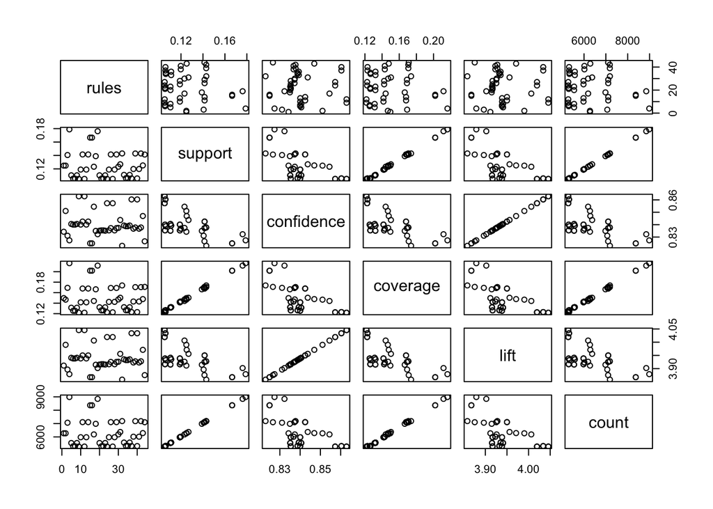

```r
# Load required packages

# Convert rules to data frame
rules_df <- as(selected_rules, "data.frame")

# Plot scatter plots for support vs. confidence and support vs. lift
plot(rules_df, method = "scatterplot")
```

```
## Available control parameters (with default values):
## layout    =  stress
## circular  =  FALSE
## ggraphdots    =  NULL
## edges     =  <environment>
## nodes     =  <environment>
## nodetext  =  <environment>
## colors    =  c("#EE0000FF", "#EEEEEEFF")
## engine    =  ggplot2
## max   =  100
## verbose   =  FALSE
```

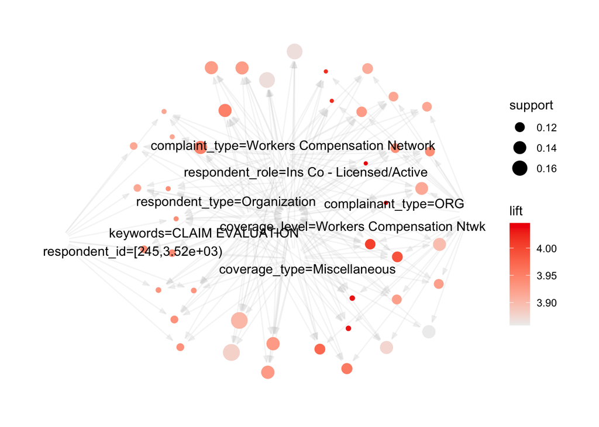

```r
plot(selected_rules, method = "graph", control = list(type="items"))
```

```r
# Convert your data to transactions
transactions <- as(insurance_df, "transactions")
# Perform association rule mining
rules <- apriori(transactions)
```

```
## Apriori
##
## Parameter specification:
##  confidence minval smax arem  aval originalSupport maxtime support minlen
##         0.8    0.1    1 none FALSE            TRUE       5     0.1      1
##  maxlen target  ext
##      10  rules TRUE
##
## Algorithmic control:
##  filter tree heap memopt load sort verbose
##     0.1 TRUE TRUE  FALSE TRUE    2    TRUE
##
## Absolute minimum support count: 5023
##
## set item appearances ...[0 item(s)] done [0.00s].
## set transactions ...[905 item(s), 50238 transaction(s)] done [0.07s].
## sorting and recoding items ... [33 item(s)] done [0.00s].
## creating transaction tree ... done [0.01s].
## checking subsets of size 1 2 3 4 5 6 7 8 9 10
```

```
##  done [0.03s].
## writing ... [35590 rule(s)] done [0.00s].
## creating S4 object  ... done [0.01s].
```

```r
# Extract lift values from the rules
lift_values <- quality(rules)$lift

# Find the indices of the rules with the highest lift values
top_lift_indices <- order(lift_values, decreasing = TRUE)[1:10]  # Adjust the number as needed

# Extract the top rules based on lift
top_lift_rules <- rules[top_lift_indices]

# Extract itemsets from the top rules
top_lift_lhs <- labels(lhs(top_lift_rules))
top_lift_rhs <- labels(rhs(top_lift_rules))

# Combine lhs and rhs to get all variables involved in the top rules
all_variables <- c(top_lift_lhs, top_lift_rhs)

# Remove duplicates and sort the variables
unique_variables <- sort(unique(all_variables))

# Print the list of variables
print("List of Variables:")
```

```
## [1] "List of Variables:"
```

```r
print(unique_variables)
```

```
##  [1] "{complaint_type=Workers Compensation Network,coverage_type=Miscellaneous,complainant_type=ORG,keywords=CLAIM EVALUATION}"
##  [2] "{complaint_type=Workers Compensation Network,coverage_type=Miscellaneous,respondent_role=Ins Co - Licensed/Active,complainant_type=ORG,keywords=CLAIM EVALUATION}"
##  [3] "{complaint_type=Workers Compensation Network,coverage_type=Miscellaneous,respondent_role=Ins Co - Licensed/Active,respondent_type=Organization,complainant_type=ORG,keywords=CLAIM EVALUATION}"
##  [4] "{complaint_type=Workers Compensation Network,coverage_type=Miscellaneous,respondent_type=Organization,complainant_type=ORG,keywords=CLAIM EVALUATION}"
##  [5] "{complaint_type=Workers Compensation Network,respondent_role=Ins Co - Licensed/Active,complainant_type=ORG,keywords=CLAIM EVALUATION}"
##  [6] "{complaint_type=Workers Compensation Network,respondent_role=Ins Co - Licensed/Active,respondent_type=Organization,complainant_type=ORG,keywords=CLAIM EVALUATION}"
##  [7] "{coverage_level=Workers Compensation Ntwk}"
##  [8] "{coverage_type=Miscellaneous,complainant_type=ORG,keywords=CLAIM EVALUATION}"
##  [9] "{coverage_type=Miscellaneous,respondent_role=Ins Co - Licensed/Active,complainant_type=ORG,keywords=CLAIM EVALUATION}"
## [10] "{coverage_type=Miscellaneous,respondent_role=Ins Co - Licensed/Active,respondent_type=Organization,complainant_type=ORG,keywords=CLAIM EVALUATION}"
## [11] "{coverage_type=Miscellaneous,respondent_type=Organization,complainant_type=ORG,keywords=CLAIM EVALUATION}"
```

# Feautre Selection

#complaint_type,coverage_type,complainant_type,keywords,respondent_role,respondent_type,coverage_level

```r
chi_sq_results <- data.frame(variable = character(), p_value = numeric(), stringsAsFactors = FALSE)

predictive_variables <- c(
  "complaint_filed_against", "complaint_filed_by",
  "reason_complaint_filed", "confirmed_complaint",
  "how_resolved", "complaint_type",
  "coverage_type", "coverage_level",
  "others_involved", "respondent_id",
  "respondent_role", "respondent_type", "keywords",
  "date_difference"
)

response_variables <- c("complaint_type")

for (var in predictive_variables) {
  chi_sq <- chisq.test(insurance_df[[var]], insurance_df[[response_variables]])
  p_value <- chi_sq$p.value
  chi_sq_results <- rbind(chi_sq_results, data.frame(variable = var, p_value = p_value))
}
significant_predictors_chi_sq <- chi_sq_results$variable[chi_sq_results$p_value < 0.05]
significant_predictors_chi_sq
```

```
##  [1] "complaint_filed_against" "complaint_filed_by"
##  [3] "reason_complaint_filed"  "confirmed_complaint"
##  [5] "how_resolved"            "complaint_type"
##  [7] "coverage_type"           "coverage_level"
##  [9] "others_involved"         "respondent_id"
## [11] "respondent_role"         "respondent_type"
## [13] "keywords"                "date_difference"
```

For each predictor variable listed, the p-value of the chi-squared test is calculated. If the p-value is less than 0.05, it indicates that there is evidence to reject the null hypothesis that there is no association between the predictor variable and the response variable. Therefore, these predictor variables are considered significant in predicting the response variable “complaint_type”.

```r
library(tidytext)
book1_counts <- insurance_df |>
  summarize(term_frequency = n(),
            .by = c(keywords)) |>
  arrange(desc(term_frequency))

book1_counts |>
  head()
```

```
##                         keywords term_frequency
## 1               CLAIM EVALUATION          27748
## 2 OUT-OF-NTWK PRVDR MEDIATION RQ           6885
## 3                 EMERGENCY CARE           3607
## 4 MED PROVIDER/THIRDPARTY BILLER           2281
## 5                   PRESCRIPTION           1546
## 6            ADJUSTER'S HANDLING           1032
```

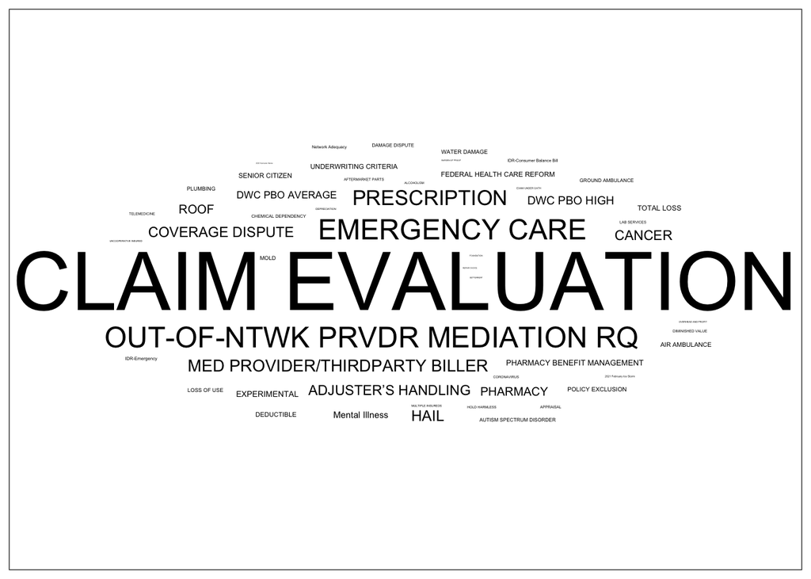

```r
book1_counts |>
  group_by(keywords) |>
  summarize(term_frequency = sum(term_frequency)) |>
  slice_max(term_frequency,
            n = 50) |>
  ggplot() +
  geom_text_wordcloud_area(aes(label = keywords,
                               size = term_frequency)) +
  scale_size_area(max_size = 70)
```

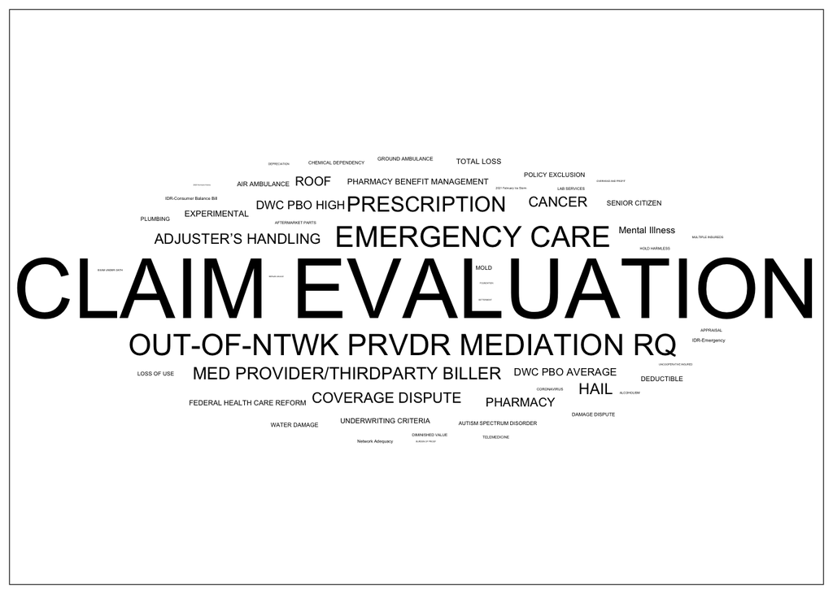

```r
# eliminating stop words

data("stop_words")

stop_words <- stop_words |> rename( keywords  = word )

book1_counts_clean <- book1_counts |>
  anti_join(stop_words,
            by = join_by(keywords))

book1_counts_clean |>
  slice_max(term_frequency,
            n = 50) |>
  ggplot() +
  geom_text_wordcloud_area(aes(label = keywords,
                               size = term_frequency)) +
  scale_size_area(max_size = 70)
```

[figure not shown]

```r
ggplot(data = insurance_df, aes(x = complaint_filed_against)) +
  geom_bar(fill = "skyblue", color = "black") +
  geom_text(stat = 'count', aes(label = ..count..), vjust = -0.2) +  # Add counts on top of each bar
  labs(title = "complaint_filed_against") +
  theme_minimal() +
  theme(axis.text.x = element_text(angle = 90, hjust = 1))
```

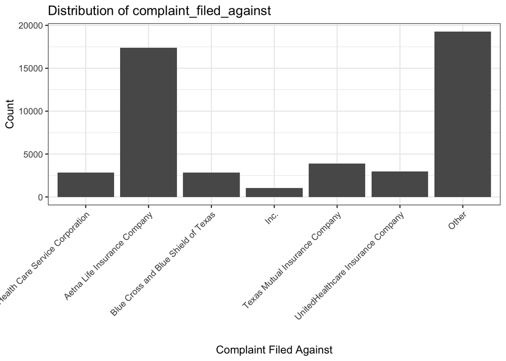

```r
# Define the recipe
recipe_ames <- recipe(data = insurance_df, formula = complaint_type ~ .)

# Apply 'step_other' to handle infrequent levels in 'complaint_filed_against'
recipe_ames <- recipe_ames |>
  step_other(complaint_filed_against,
             threshold = 0.02,    # Threshold to determine infrequent levels
             other = "Other")    # Label for infrequent levels

# Apply the recipe to the data
processed_data <- recipe_ames %>%
  prep() %>%
  bake(new_data = insurance_df)

# Create a bar plot to visualize the distribution of 'complaint_filed_against'
ggplot(processed_data, aes(x = complaint_filed_against)) +
  geom_bar() +
  labs(title = "Distribution of complaint_filed_against",
       x = "Complaint Filed Against",
       y = "Count") +
  theme(axis.text.x = element_text(angle = 45, hjust = 1))  # Rotate x-axis labels for better readability
```